# The Carpentries Instructor Training Assessment Report

## 5.2 Checkout and Certification

One potential opportunity for improvement is in our Instructor Training program is related to checkout. Specifically, we could work to reduce the number of individuals who participate in the training, but do not complete the instructor certification process. As mentioned previously, the goals of our Instructor Training program are twofold: 1) Certify new instructors who will go on to teach our workshops, but 2) To provide training in our pedagogy to those interested in improving their teaching practices regardless of whether they plan to teach for The Carpentries. With that in mind, our goal is not to have an instructor certification rate of 100%. However, if there are trainees who intend to certify but do not complete the checkout process, this may be an opportunity.

Our overall certification rate, since 2013, is 51.3% and has ranged from 44% in 2014 to 57% in 2015. Between 2017 - 2019, we saw a steady decline in the certification rate. In 2020, the certification rate increased slightly (from 54% in 2019 to 55% in 2020).

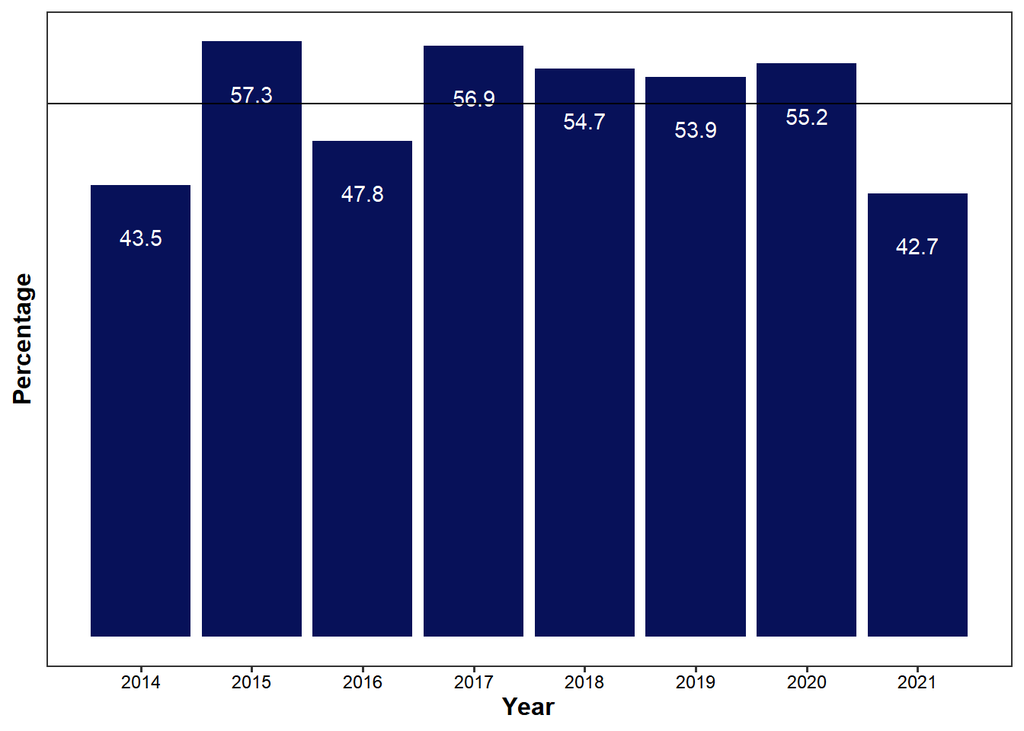

Figure 5.2: Percentage of Trainees Who Certify as Instructors

### 5.2.1 The Checkout Process

After completing Instructor Training, there are three steps to [“checkout”, that is, become a certified Instructor](https://carpentries.github.io/instructor-training/checkout/). Those three steps are:

1. Homework: Contribute to The Carpentries lessons or glossary;
2. Discussion: Take part in an online community discussion session; and
3. Demo: Teach a short demonstration lesson.

At the time trainees take their post-workshop survey, the vast majority say they understand the checkout process.

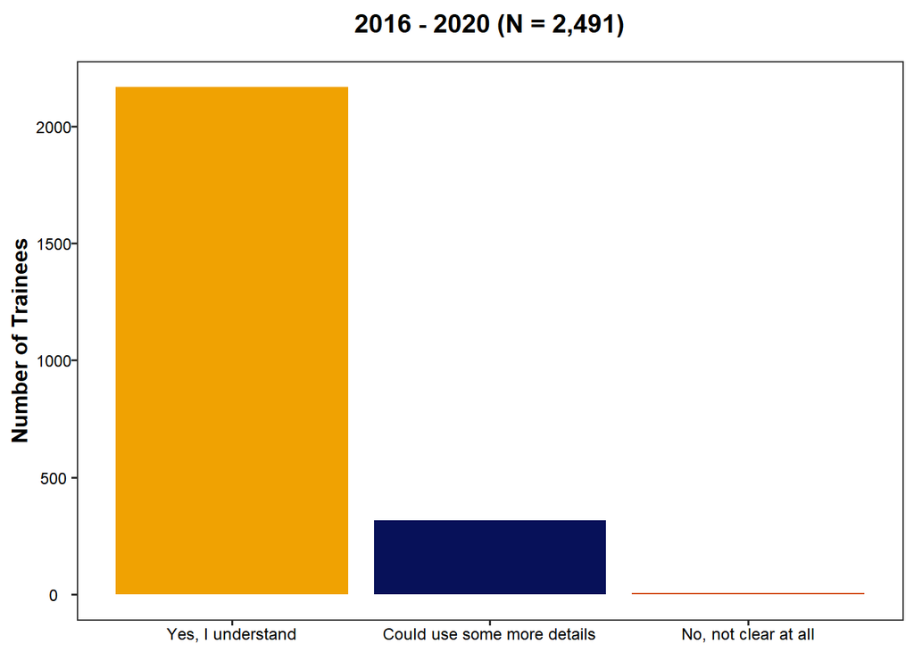

Figure 5.3: Instructor Trainees’ Understanding of What Needs to be Done to Complete Instructor Training

However, between 2019 and 2020, only 57% of trainees completed all three checkout steps, 28% of trainees completed no checkout steps, and 15% completed just one or two of the steps. We do not yet measure how many trainees intend to checkout. However, we assume that trainees who started the checkout process did have this intention. In seeking to reduce barriers to checkout and increase the number of certified Instructors, this 15% of trainees who begin but do not complete checkout may be a good place to start.

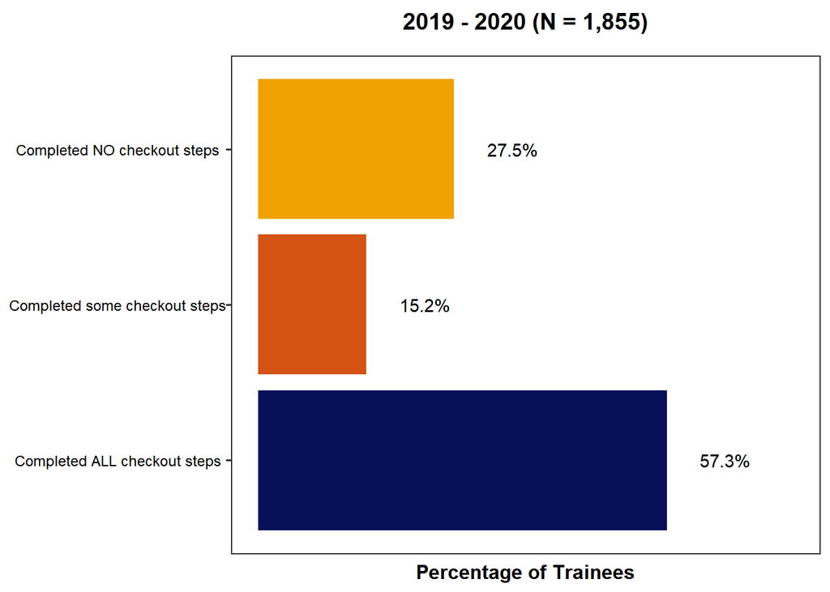

Figure 5.4: Percentage of Trainees Who Start Checkout

If we are to address why some trainees begin but do not complete checkout, it is helpful to understand what steps they complete and where they may get stuck.

Of the 282 trainees that did not complete checkout between 2019 and 2020, 240 (or 85%) attended a community discussion, while only 83 (29%) and 64 (23%) trainees completed the teaching demonstration and lesson contribution, respectively.

These results suggest that focusing our efforts on the teaching demonstration and lesson contribution steps could increase the checkout rate and, in turn, the number of certified Carpentries Instructors. Possible next steps to help more trainees complete the teaching demonstration and lesson contribution include:

- looking for opportunities to clarify instructions or expectations,
- providing additional support to trainees through these steps, and
- considering whether any changes need to be made to the formats.

Updates have already been proposed to the instructions housed in the Instructor Training Curriculum that may begin to address some of these challenges. The Instructor Training Team will be working with the Trainers Leadership Group, the Maintainers community, and other relevant stakeholders towards further addressing next steps in the coming months.

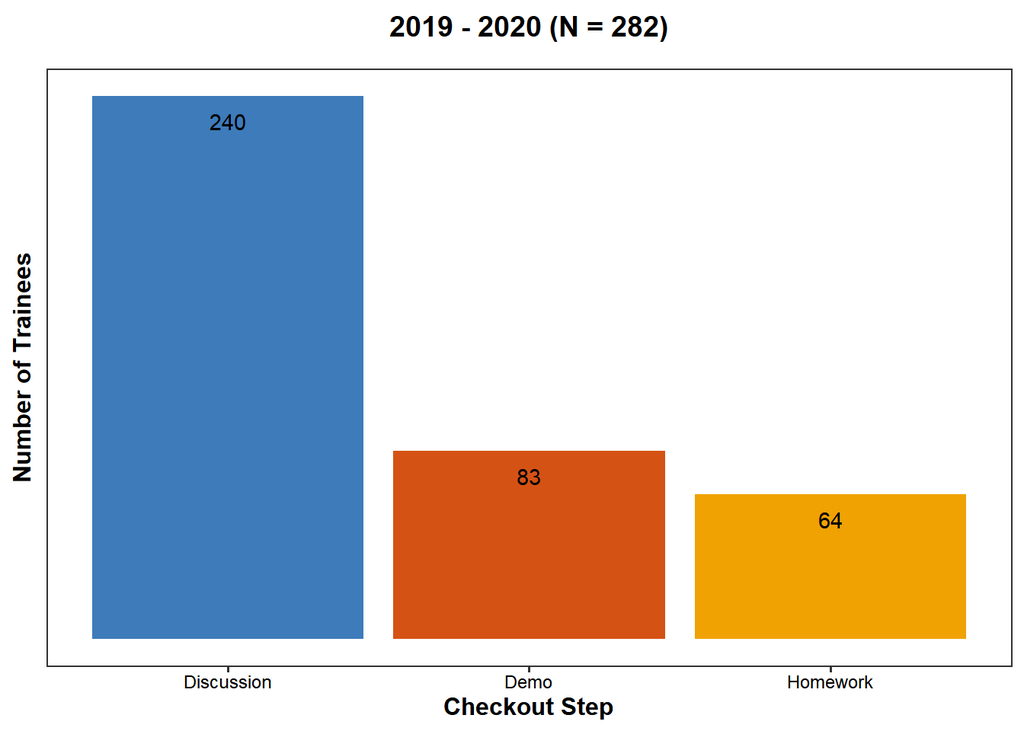

Figure 5.5: Number of Trainees Who Complete Each Checkout Step

### 5.2.2 Time from Training to Certified Instructor

Another checkout factor to consider is the time it takes a trainee to complete certification. In 2020, trainees took a median of 78 days from finishing training to completing certification or just under three months.

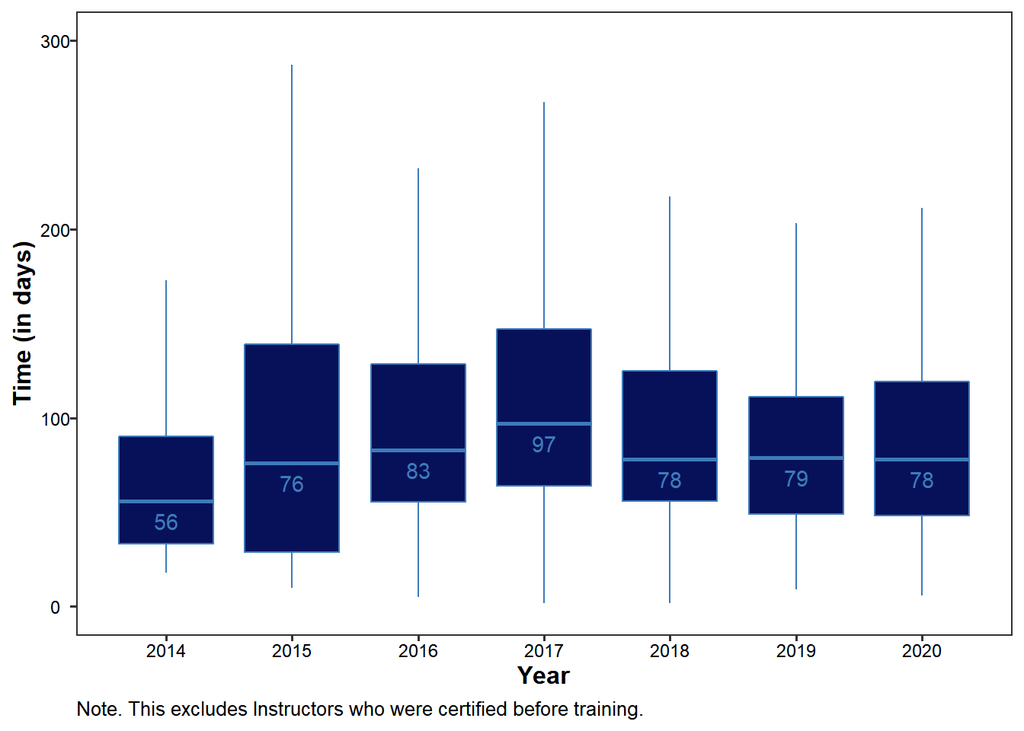

Figure 5.6: Median Time from Instructor Training to Certification

## 5.3 Instructor Teaching Activity

Once Instructors are certified, we are interested in how active they are. To start, it is helpful to look at how long it takes for a new Instructor to teach their first workshop.

The graph below shows the median time from completing Instructor Training to teaching your first workshop. Note that someone can teach a Carpentries workshop without being certified as long as they teach with a certified Instructor. In this analysis, we are excluding those who taught before they were certified. The median time from completing Instructor Training to teaching your first workshop has ranged from 185 days in 2015 to 82 days in 2017. In 2020, the average number of days was 182, or just under six months.

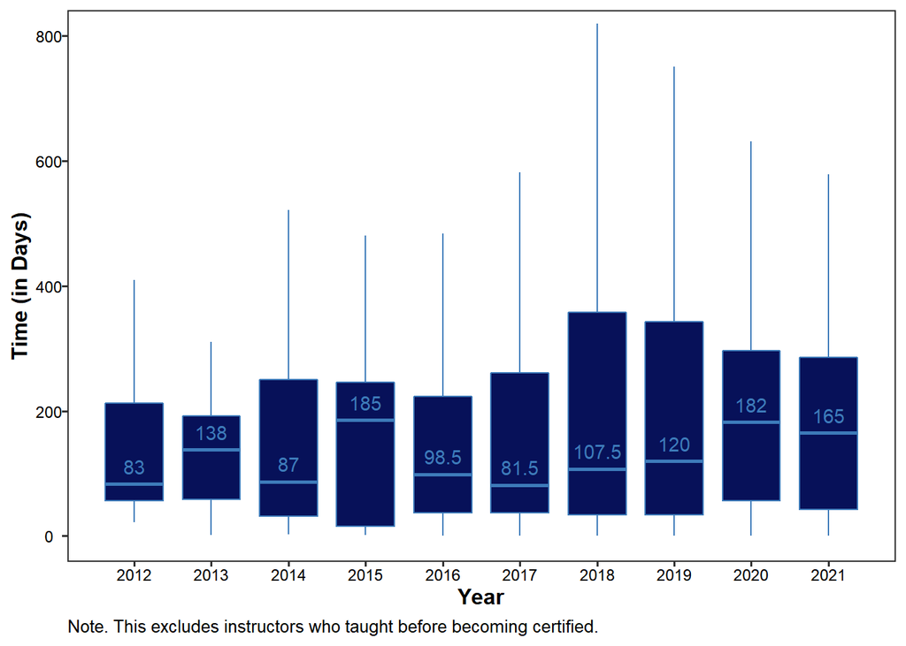

Figure 5.7: Median Time from Instructor Training to First Time Teaching

Once Instructors begin teaching, it is helpful to understand how often they teach.

The following graph includes all Instructors, certified and not certified, who have taught a Carpentries workshop. The greatest number of Instructors have taught one workshop. However, the number of Instructors who have taught between 2 and 5 workshops is almost as high. The vast majority of Instructors fall into these two categories. However, we also have over 300 Instructors who have taught 6 or more workshops. **Note that the graph below does not include certified Instructors who have never taught a workshop.**

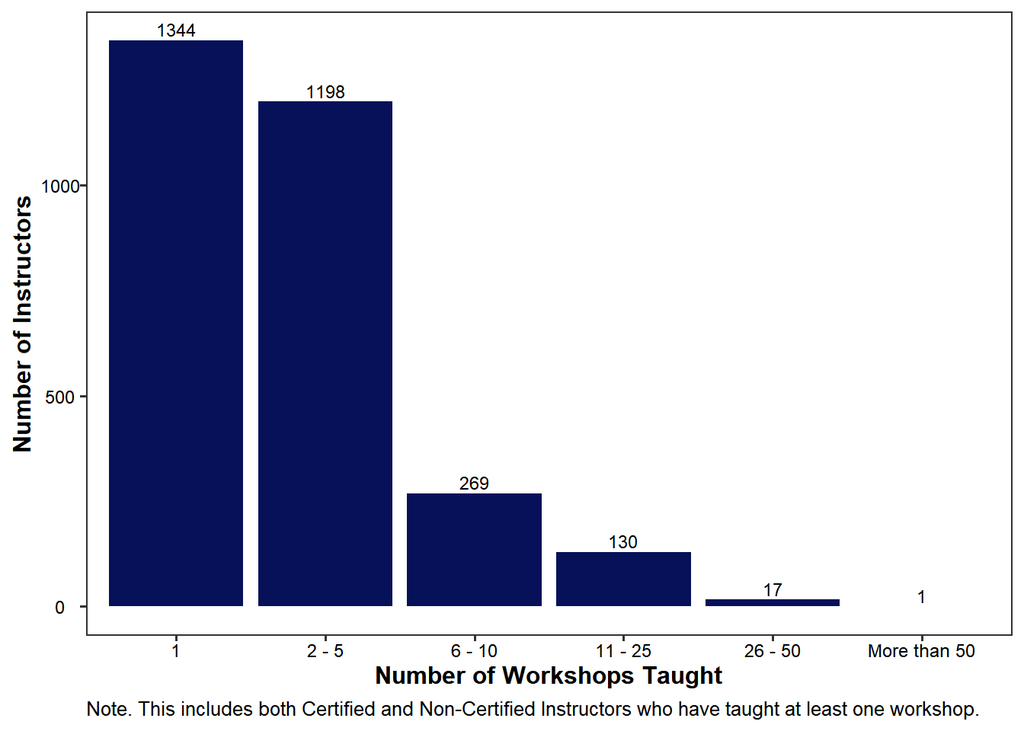

Figure 5.8: Number of Total Workshops Instructors Have Taught

## 5.4 Summary of Instructor Certification and Teaching

From 2017 - 2019, we certified between 464 and 625 new Instructors annually. This number was consistently increasing until 2020, where challenges related to the pandemic affected our efforts and outcomes. The certification rate was 54% in 2019 rising slightly to 55% in 2020.

We have determined that 28% of trainees never begin checkout, while 15% complete some but not all of the steps. Of those steps, trainees attend a community discussion most often followed by a substantial drop in those who complete the teaching demonstration or lesson contribution steps. These data reveal an opportunity to increase support for the teaching demonstration and lesson contribution steps, increasing our certification rate.

After certification, we find that Instructors typically teach their first workshop within 6 months. Most Instructors teach between 1 and 5 workshops, but we have a small but active group of over 300 Instructors that have taught more than 6.

# 6 Growth of Instructor Training Efforts

The Carpentries received [a grant from the Chan Zuckerberg Initiative](https://carpentries.org/blog/2019/11/czi-moore-grant/) in which we committed to growing our Instructor and Trainer Training Efforts by 2022.

Our primary metric to reflect efforts is the number of Instructors and Trainers trained. This number is more valuable than the number of trainings run because trainings have varying numbers of trainees and do not reflect efforts directed towards increased efficiency. Instructors **trained** is also more useful than Instructors **certified** because certifications rely on downstream factors (e.g., local community support for checkout completion) in addition to efforts toward expanding access to training.

## 6.1 The Impact of the Global COVID-19 Pandemic

Since 2020, the world has been fighting a global COVID-19 pandemic. The pandemic has created a great deal of uncertainty for individuals and organizations around the globe. Throughout this report, the effects of this uncertainty are reflected in a decrease in our data. As parts of the world begin to open up, we look forward to being able to train more people again.

## 6.2 Number of Trained Instructor Trainers

Until 2016, Software Carpentry founder and former Executive Director Greg Wilson ran all Instructor Training events himself online. Knowing the limitations of having only one Instructor Trainer, in 2016, The Carpentries began training additional Instructor Trainers (aka “Trainers” in Carpentries contexts).

Training additional Instructor Trainers expanded our reach, allowing us to run several Instructor Training events a month across different time zones. It also allowed us to build capacity at member organizations that have onsite Instructor Trainers. These Trainers run events for their institution, building a community of trained and certified instructors there. By bringing on new Trainers in many parts of the world, we create a global Trainer community. This international community has expanded our geographic reach, allowing us to reach communities with which we may not otherwise connect.

The Carpentries Trainer community comprises experienced Instructors and others with advanced educational training or related expertise who inspire and prepare the next wave of Instructors in our community. They work as a team to maintain and teach the [Instructor Training curriculum](https://carpentries.github.io/instructor-training/) to prepare prospective Instructors to join The Carpentries community.

As of August 2021, The Carpentries has 98 certified Trainers. Unlike Instructors, certified Instructor Trainers are asked to select “inactive” status if they are unable to continue participating in their role.

In 2019, we certified 10 new Trainers. In 2020, we trained two cohorts of new Trainers and certified our highest number of Trainers in one year to date, 29. In July 2021, we certified an additional 14 new Trainers.

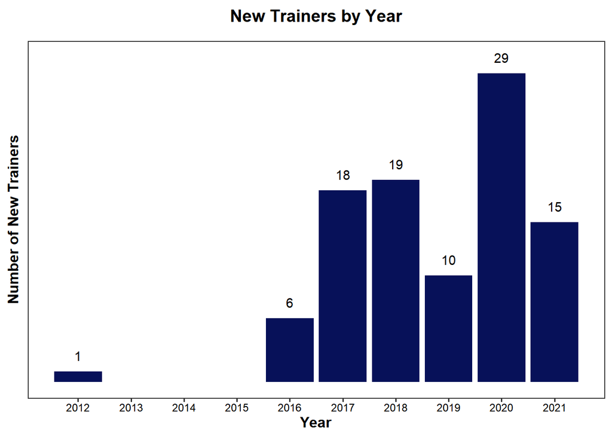

## 6.3 Number of Trained Instructors

As of August 2021, The Carpentries has 3,335 certified Instructors. Note that once an Instructor is certified, they remain certified indefinitely. Thus, this number does not reflect the current number of active Instructors.

The Carpentries trained 1,168 people in Instructor Training in 2019. This was a 12.5% increase from 2018 and a 42.6% increase from 2017.

Before 2020, the number of people we trained increased year on year. In 2020, despite the pandemic, we still taught 895 people. This decrease of 23% resulted in a number of trainees on par with our efforts in 2017.

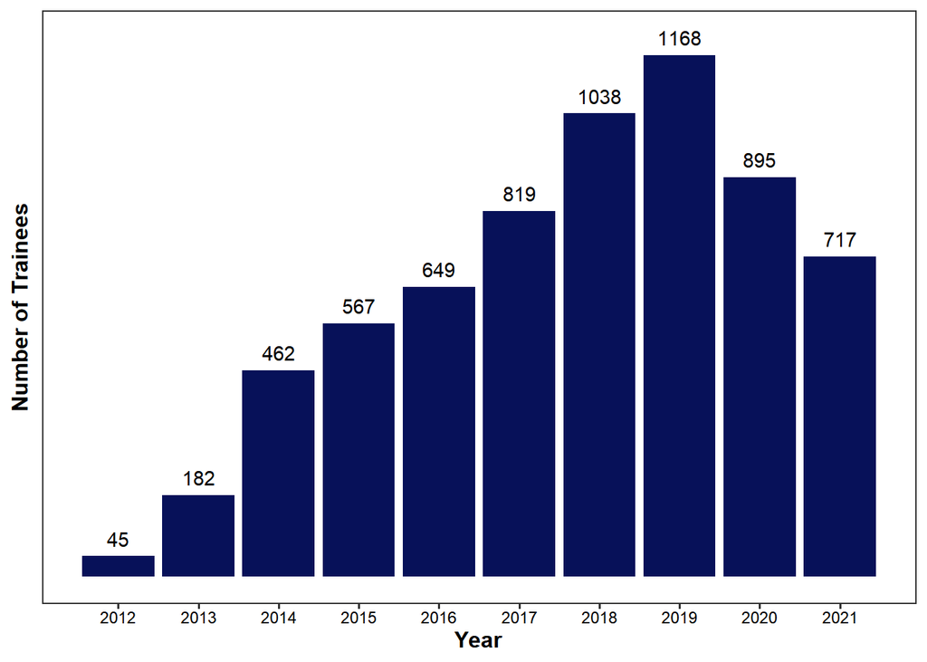

Figure 6.1: People Trained in Instructor Training by Year

## 6.4 Number of Instructor Trainings

In 2019, The Carpentries ran 67 Instructor Trainings. This was similar to the 70 trainings we ran in 2018, but a 36.7% increase from 2017. In 2020, we were able to host 49 Instructor Trainings. This 26% decrease also reflected a return to levels similar to 2017.

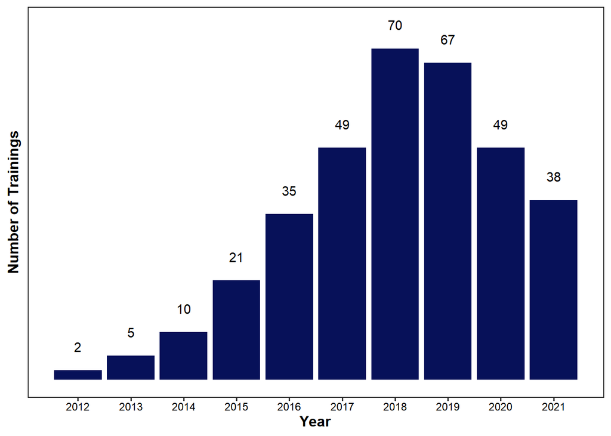

Figure 6.2: Instructor Trainings by Year

## 6.5 Pipelines for Trainees: Member vs. Open

Most of our trainees are trained through organisational agreements with affiliated institutions or groups, also called [Memberships](https://carpentries.org/membership/). Others are accepted through our Open Application program. The Open Application program is a limited scholarship program where people not trained through a Membership can attend Instructor Training free of charge. In 2020, 716 individuals were trained through a Membership while 178 were trained through the Open Application program.

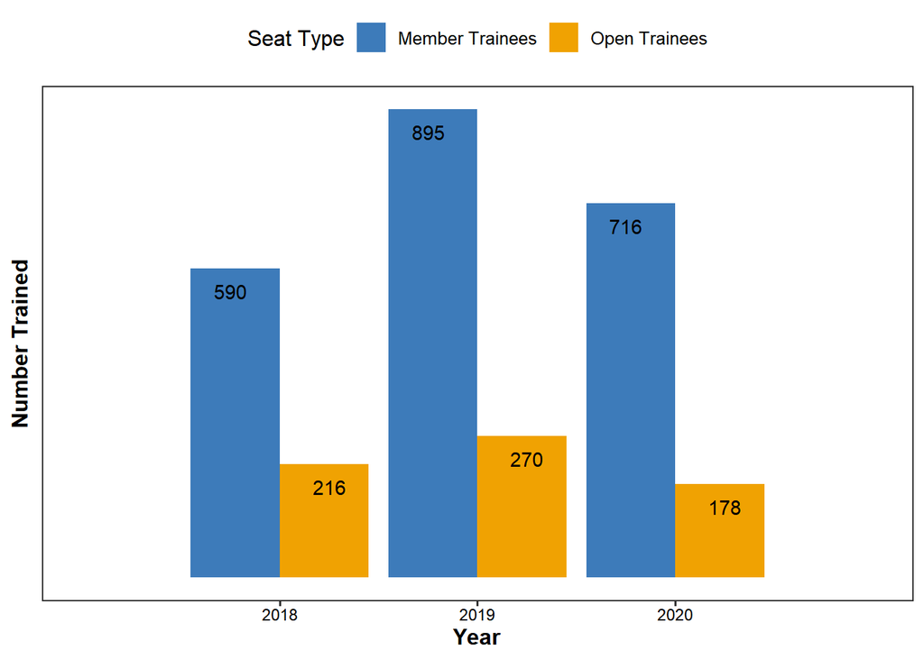

Figure 6.3: Number of People Trained Through Membership Versus Open Applications

Before 2018, we could not separate trainees by whether they were trained as part of a Membership Agreement or through our Open Training program.

From 2018 to 2019, we saw an 51.7% increase in those being trained under a membership agreement and a 25% increase in those being trained through Open Training.

# 7 Conclusion

## 7.1 Summary

The purposes of this report are to:

- provide an update on the growth, successes, and challenges of the Instructor Training program to the Executive Council, Trainers Leadership Group, Trainers, and broader Carpentries community.
- help the Instructor training team, Core Team, Executive Council, and Trainers Leadership Group identify trends and opportunities that can drive continuous program improvement.

The report is comprised of three main components: 1) Instructor Training Outcomes, 2) Instructor Certification and Teaching, and 3) Growth of Instructor Training Efforts.

### 7.1.1 Instructor Training Outcomes

Results from our pre and post-Instructor Training surveys demonstrate that trainees learn new skills and knowledge, have more motivation to learn and feel the training was worth their time. They rate our Trainers as strong communicators, considerate, and enthusiastic. Trainees also report they are very likely to recommend Instructor Training to others. This point is significant as the majority of trainees find about Instructor Training through word-of-mouth.

### 7.1.2 Instructor Certification and Teaching

Drawing on data in our AMY database, we identified that from 2017 - 2019, we certified between 464 and 625 new Instructors annually. This number was consistently increasing until 2020, where challenges related to the pandemic affected our efforts and outcomes. The certification rate was 54% in 2019, rising slightly to 55% in 2020. We have determined that 28% of trainees never begin checkout, but 15% complete some but not all of the steps. Of those steps, most attend a community discussion followed by a substantial drop in those who complete the teaching demonstration or lesson contribution steps. These data reveal an opportunity to increase support for the teaching demonstration and lesson contribution steps, increasing our certification rate.

After certification, Instructors typically teach their first workshop within 6 months. Most Instructors teach between 1 and 5 workshops, but we have over 300 Instructors that have taught more than 6.

### 7.1.3 Growth of Instructor Training Efforts

The Carpentries received [a grant from the Chan Zuckerberg Initiative](https://carpentries.org/blog/2019/11/czi-moore-grant/) in which we committed to growing our Instructor and Trainer Training Efforts by 2022.

In 2020, we trained two cohorts of new Trainers and certified our highest number of Trainers in one year to date, 29. In July 2021, we certified a cohort of 14 new Trainers.

Instructor Training has declined during the pandemic, showing a 23% drop in the number of people trained in 2020 compared with 2019 (895 vs. 1,168). It has remained somewhat lower than average in 2021. However, we still trained almost 900 people in 2020. Recruitment and retention will continue to present a challenge in an unpredictable pandemic landscape. We look forward to finding new ways to support the ambitions of our community-members amid the challenges they face.

## 7.2 Next Steps

Work on this report will be ongoing as new questions emerge and our ability to answer them advances. This preliminary report serves as a building block to future assessment work. Areas of interest for continued development include, but are certainly not limited to:

- deeper exploration of our applicant, trainee, Instructor, and Trainer demographics as we continue to focus on equity, inclusion, and accessibility. The limited data currently available to explore these topics suggest that we need to re-examine our assessment efforts in this area.
- deeper analysis of trainee outcomes broken down by paths to training, e.g. through membership vs sponsored admission for individuals or groups.
- more comprehensive understanding of Instructor and Trainer teaching activity, including teaching frequency and retention.
- impact of curriculum updates, policy changes, and other qualitative shifts on survey responses.
- long-term assessment of Instructor Training to evaluate perspectives of Instructors as they begin to teach.

## 7.3 Final Thoughts

The success of The Carpentries Instructor Training program hinges on the strength of our outstanding Trainer community. Our Trainers create welcoming and inclusive spaces for our trainees to learn. They are knowledgeable, enthusiastic, and kind. Our Trainers donate thousands of hours to maintaining our curriculum, teaching Instructor Training, hosting teaching demonstrations, and continuing to improve their own teaching skills. Thank you to each of you for all you do.